# Assignment 4 — k-Means Clustering: Pharmaceuticals

Jaipreet Kaur

October 26, 2025

# 1 Purpose

The goal is to use **k-means clustering** to explore and understand the structure of the pharmaceutical industry using core financial variables for 21 firms.

# 2 Reproducibility Setup

```r
# Helper to install any missing packages
use_pkgs <- c(
  "tidyverse", "readr", "dplyr", "ggplot2", "tibble",
  "knitr", "kableExtra",
  "broom", "cluster", "factoextra", "janitor"
)
to_install <- setdiff(use_pkgs, rownames(installed.packages()))
if (length(to_install) > 0) install.packages(to_install, quiet = TRUE)

# Load packages
library(tidyverse)
library(readr)
library(dplyr)
library(ggplot2)
library(tibble)
library(knitr)
library(kableExtra)
library(broom)
library(cluster)
library(factoextra)
library(janitor)
```

# 3 Data Loading

**File**: `Pharmaceuticals.csv` (variables 1–12 as per assignment).  
If you knit locally, adjust `data_path` to your file location.

```r
# Path where ChatGPT placed your file when downloaded within this workspace
data_path <- "Pharmaceuticals.csv"

# If knitting on your computer and the file is elsewhere, update the path:
# data_path <- "path/to/Pharmaceuticals.csv"

raw <- read_csv(data_path, show_col_types = FALSE) %>%
  clean_names()

# Show structure
glimpse(raw)
```

```
## Rows: 21
## Columns: 14
## $ symbol                <chr> "ABT", "AGN", "AHM", "AZN", "AVE", "BAY", "BMY",…
## $ name                  <chr> "Abbott Laboratories", "Allergan, Inc.", "Amersh…
## $ market_cap            <dbl> 68.44, 7.58, 6.30, 67.63, 47.16, 16.90, 51.33, 0…
## $ beta                  <dbl> 0.32, 0.41, 0.46, 0.52, 0.32, 1.11, 0.50, 0.85, …
## $ pe_ratio              <dbl> 24.7, 82.5, 20.7, 21.5, 20.1, 27.9, 13.9, 26.0, …
## $ roe                   <dbl> 26.4, 12.9, 14.9, 27.4, 21.8, 3.9, 34.8, 24.1, 1…
## $ roa                   <dbl> 11.8, 5.5, 7.8, 15.4, 7.5, 1.4, 15.1, 4.3, 5.1, …
## $ asset_turnover        <dbl> 0.7, 0.9, 0.9, 0.9, 0.6, 0.6, 0.9, 0.6, 0.3, 0.6…
## $ leverage              <dbl> 0.42, 0.60, 0.27, 0.00, 0.34, 0.00, 0.57, 3.51, …
## $ rev_growth            <dbl> 7.54, 9.16, 7.05, 15.00, 26.81, -3.17, 2.70, 6.3…
## $ net_profit_margin     <dbl> 16.1, 5.5, 11.2, 18.0, 12.9, 2.6, 20.6, 7.5, 13.…
## $ median_recommendation <chr> "Moderate Buy", "Moderate Buy", "Strong Buy", "M…
## $ location              <chr> "US", "CANADA", "UK", "UK", "FRANCE", "GERMANY",…
## $ exchange              <chr> "NYSE", "NYSE", "NYSE", "NYSE", "NYSE", "NYSE", …
```

# 4 Variables

Per the instructions, variables are: 1. Market capitalization (in billions of dollars)  
2. Beta  
3. Price/earnings ratio  
4. Return on equity  
5. Return on assets  
6. Asset turnover  
7. Leverage  
8. Estimated revenue growth  
9. Net profit margin  
10. Median recommendation (categorical)  
11. Headquarters location (categorical)  
12. Stock exchange (categorical)

# 5 (a) Clustering on Numerical Variables (1–9)

We cluster only on variables 1–9. We standardize each variable (z-scores) to give **equal weight** in the Euclidean distance used by k-means. Missing values are imputed via median (simple, robust for small samples).

```r
# Identify numeric columns
num_cols <- raw %>% select(where(is.numeric)) %>% names()

# If there are more than 9 numeric fields, select the first 9
num_vars <- if (length(num_cols) >= 9) num_cols[1:9] else num_cols

df_num <- raw %>% select(all_of(num_vars))

# Median imputation for any missing
df_num_imp <- df_num %>% mutate(across(everything(), ~ ifelse(is.na(.x), median(.x, na.rm = TRUE), .x)))

# Standardize for k-means
df_scaled <- scale(df_num_imp)
attr_center <- attr(df_scaled, "scaled:center")
attr_scale  <- attr(df_scaled, "scaled:scale")
```

## 5.1 Choosing the Number of Clusters (k)

We assess **2–7 clusters** using: - **Elbow method** (total within-cluster sum of squares) - **Average silhouette**

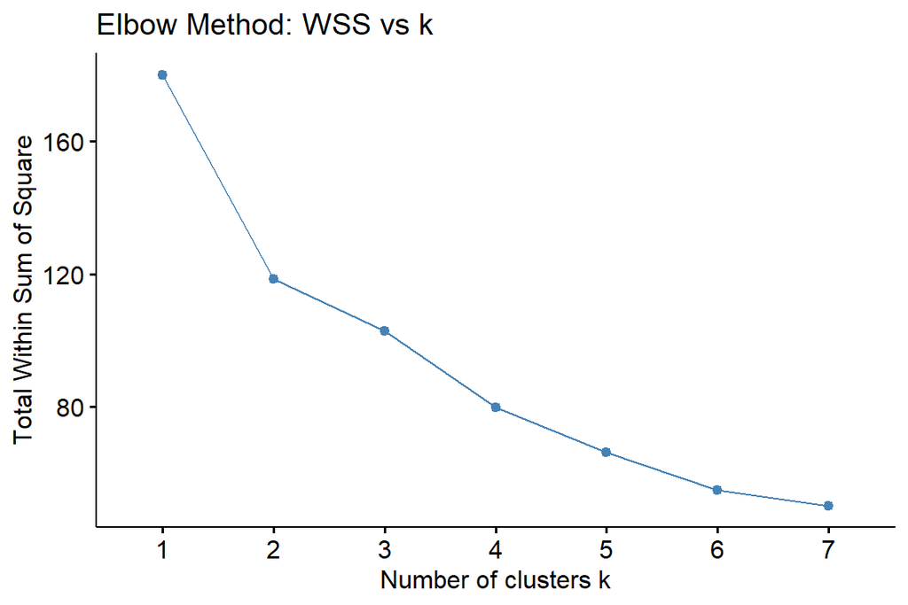

```r
set.seed(42)

k_grid <- 2:7

# Elbow: within-cluster sum of squares
fviz_nbclust(x = df_scaled, FUNcluster = kmeans, method = "wss", k.max = max(k_grid)) +
  ggtitle("Elbow Method: WSS vs k")
```

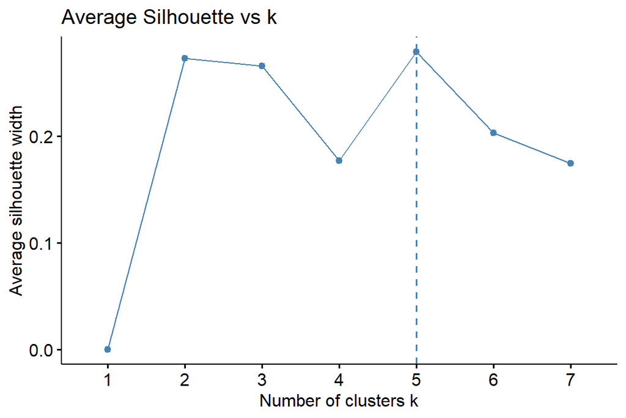

```r
# Silhouette
fviz_nbclust(x = df_scaled, FUNcluster = kmeans, method = "silhouette", k.max = max(k_grid)) +
  ggtitle("Average Silhouette vs k")
```

Compute and print precise silhouette scores for transparency:

```r
set.seed(42)
sil_tbl <- map_dfr(k_grid, function(k){
  km <- kmeans(df_scaled, centers = k, nstart = 50, iter.max = 100)
  sil <- silhouette(km$cluster, dist(df_scaled))
  tibble(k = k, silhouette_avg = mean(sil[, "sil_width"], na.rm = TRUE))
})

knitr::kable(sil_tbl, digits = 3, caption = "Average silhouette by k") %>%
  kableExtra::kable_styling(full_width = FALSE)
```

Average silhouette by k

| k | silhouette_avg |
| --- | --- |
| 2 | 0.273 |
| 3 | 0.280 |
| 4 | 0.225 |
| 5 | 0.249 |
| 6 | 0.250 |
| 7 | 0.228 |

## 5.2 Final Model

```r
set.seed(42)

# Choose k as the argmax of the average silhouette
best_k <- sil_tbl %>% arrange(desc(silhouette_avg)) %>% slice(1) %>% pull(k)

final_km <- kmeans(df_scaled, centers = best_k, nstart = 100, iter.max = 200)

# Attach cluster labels to the original data
res <- raw %>% mutate(cluster = factor(final_km$cluster))

cluster_sizes <- table(res$cluster)
cluster_sizes
```

```
##
##  1  2  3
## 11  4  6
```

# 6 (b) Interpret Clusters (Numerical Variables)

We profile clusters by comparing **cluster-wise means** (original scale) and **standardized centroids** (z-scores).

```r
# Cluster means in original scale
cluster_means <- res %>%
  group_by(cluster) %>%
  summarise(across(all_of(num_vars), mean, na.rm = TRUE), .groups = "drop")

# Standardized centroids
centroids_scaled <- as_tibble(final_km$centers) %>% mutate(cluster = factor(1:nrow(.)), .before = 1)

# Nicely formatted tables
knitr::kable(cluster_means, digits = 3, caption = "Cluster means (original scale)") %>%
  kableExtra::kable_styling(full_width = FALSE)
```

Cluster means (original scale)

| cluster | market_cap | beta | pe_ratio | roe | roa | asset_turnover | leverage | rev_growth | net_profit_margin |
| --- | --- | --- | --- | --- | --- | --- | --- | --- | --- |
| 1 | 97.114 | 0.434 | 20.955 | 35.7 | 14.955 | 0.800 | 0.325 | 10.165 | 20.173 |
| 2 | 21.755 | 0.595 | 46.900 | 11.3 | 5.100 | 0.750 | 0.305 | 7.010 | 6.650 |
| 3 | 9.235 | 0.648 | 19.433 | 17.3 | 5.983 | 0.483 | 1.250 | 23.490 | 13.517 |

```r
knitr::kable(centroids_scaled %>% mutate(across(-cluster, round, 2)),
             caption = "Standardized centroids (z-scores)") %>%
  kableExtra::kable_styling(full_width = FALSE)
```

Standardized centroids (z-scores)

| cluster | market_cap | beta | pe_ratio | roe | roa | asset_turnover | leverage | rev_growth | net_profit_margin |
| --- | --- | --- | --- | --- | --- | --- | --- | --- | --- |
| 1 | 0.67 | -0.36 | -0.28 | 0.66 | 0.83 | 0.46 | -0.33 | -0.29 | 0.68 |
| 2 | -0.61 | 0.27 | 1.31 | -0.96 | -1.02 | 0.23 | -0.36 | -0.58 | -1.38 |
| 3 | -0.83 | 0.48 | -0.37 | -0.56 | -0.85 | -1.00 | 0.85 | 0.92 | -0.33 |

Visualize standardized centroids to see which variables drive each cluster:

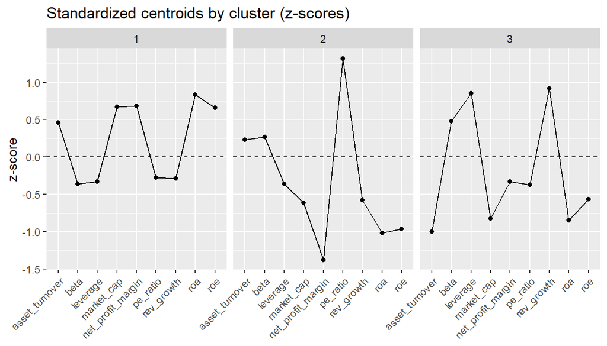

```r
centroids_long <- centroids_scaled %>%
  pivot_longer(-cluster, names_to = "variable", values_to = "z")

ggplot(centroids_long, aes(x = variable, y = z, group = cluster)) +
  geom_line() +
  geom_point() +
  facet_wrap(~ cluster, nrow = 1) +
  geom_hline(yintercept = 0, linetype = "dashed") +
  labs(title = "Standardized centroids by cluster (z-scores)",
       x = NULL, y = "z-score") +
  theme(axis.text.x = element_text(angle = 45, hjust = 1))
```

# 7 (c) Patterns with Non‑Numerical Variables (10–12)

Although these were not used for clustering, we check for post-hoc associations:  
- **Median recommendation**  
- **Headquarters location**  
- **Stock exchange**

```r
# Try to identify likely categorical columns as those not in the 1–9 numeric set
cat_candidates <- setdiff(names(raw), c(num_vars))

# Exclude any automatically added helper fields if present
cat_candidates <- setdiff(cat_candidates, c())

cat_candidates
```

```
## [1] "symbol"                "name"                  "median_recommendation"
## [4] "location"              "exchange"
```

```r
# For each candidate categorical, create a cross-tab with clusters
xt_list <- list()
for (v in cat_candidates) {
  tab <- table(res$cluster, pull(raw, v))
  xt_list[[v]] <- tab
}

# Print cross-tabs and (if feasible) chi-squared test results
for (v in names(xt_list)) {
  cat("\n\n###", v, "\n")
  print(xt_list[[v]])
  # Only run chi-squared if table has at least 2x2
  if (nrow(xt_list[[v]]) >= 2 && ncol(xt_list[[v]]) >= 2) {
    suppressWarnings({
      cs <- chisq.test(xt_list[[v]])
      print(cs)
    })
  }
}
```

```
##
##
## ### symbol
##
##     ABT AGN AHM AVE AZN BAY BMY CHTT ELN GSK IVX JNJ LLY MRK MRX NVS PFE PHA
##   1   1   0   0   0   1   0   1    0   0   1   0   1   1   1   0   1   1   0
##   2   0   1   1   0   0   1   0    0   0   0   0   0   0   0   0   0   0   1
##   3   0   0   0   1   0   0   0    1   1   0   1   0   0   0   1   0   0   0
##
##     SGP WPI WYE
##   1   1   0   1
##   2   0   0   0
##   3   0   1   0
##
##  Pearson's Chi-squared test
##
## data:  xt_list[[v]]
## X-squared = 42, df = 40, p-value = 0.3843
##
##
##
## ### name
##
##     Abbott Laboratories Allergan, Inc. Amersham plc AstraZeneca PLC Aventis
##   1                   1              0            0               1       0
##   2                   0              1            1               0       0
##   3                   0              0            0               0       1
##
##     Bayer AG Bristol-Myers Squibb Company Chattem, Inc Elan Corporation, plc
##   1        0                            1            0                     0
##   2        1                            0            0                     0
##   3        0                            0            1                     1
##
##     Eli Lilly and Company GlaxoSmithKline plc IVAX Corporation
##   1                     1                   1                0
##   2                     0                   0                0
##   3                     0                   0                1
##
##     Johnson & Johnson Medicis Pharmaceutical Corporation Merck & Co., Inc.
##   1                 1                                  0                 1
```

[output cut: 44 more lines]

```
## X-squared = 16.815, df = 12, p-value = 0.1567
##
##
##
## ### exchange
##
##     AMEX NASDAQ NYSE
##   1    0      0   11
##   2    0      0    4
##   3    1      1    4
##
##  Pearson's Chi-squared test
##
## data:  xt_list[[v]]
## X-squared = 5.5263, df = 4, p-value = 0.2374
```

# 8 (d) Name Each Cluster

We generate heuristic names from the standardized centroids by flagging large positive/negative z-scores. You can edit labels to be more business-friendly after reviewing the profiles.

```r
threshold <- 0.9  # adjust if needed
centroids_scaled_named <- centroids_scaled

make_name <- function(row) {
  highs <- names(row)[row >=  threshold]
  lows  <- names(row)[row <= -threshold]
  highs <- setdiff(highs, "cluster")
  lows  <- setdiff(lows,  "cluster")
  parts <- c(
    if (length(highs)) paste0("High ", paste(head(highs, 3), collapse = ", ")),
    if (length(lows))  paste0("Low ", paste(head(lows, 3), collapse = ", "))
  )
  if (length(parts) == 0) "Balanced Profile" else paste(parts, collapse = " | ")
}

labels <- apply(centroids_scaled_named, 1, make_name)
cluster_labels <- tibble(cluster = centroids_scaled$cluster, label = labels)

knitr::kable(cluster_labels, caption = "Heuristic cluster names") %>%
  kableExtra::kable_styling(full_width = FALSE)
```

Heuristic cluster names

[output not shown]

# 9 Cluster Visualization

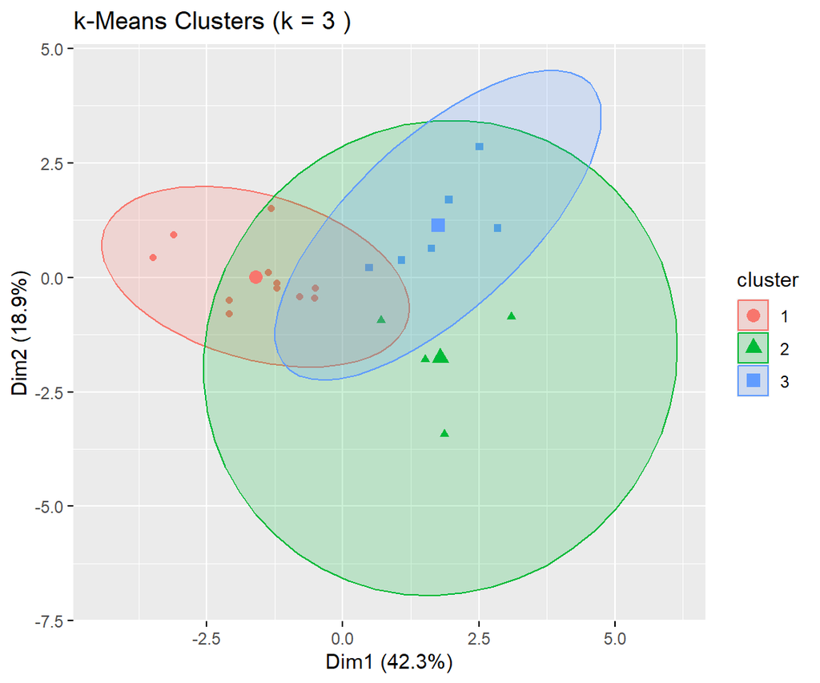

```r
fviz_cluster(list(data = df_scaled, cluster = final_km$cluster),
             geom = "point", ellipse.type = "norm",
             main = paste("k-Means Clusters (k =", best_k, ")"))
```

# 10 (10) Discussion & Justification

**Preprocessing:**  
All numerical variables were standardized to z-scores to ensure that measures on different scales (e.g., Market Capitalization vs. Asset Turnover) contribute equally to the distance calculations. Median imputation was applied to handle any missing values, as it is a robust method that minimizes distortion for small datasets.

**Algorithm Selection:**  
The **k-Means clustering** algorithm was chosen due to its efficiency, interpretability, and suitability for identifying compact, roughly spherical clusters in Euclidean space. It provides straightforward cluster centroids that can be directly compared across financial dimensions, making it appropriate for an exploratory industry segmentation analysis.

**Choice of *k* (Number of Clusters):**  
The optimal number of clusters was determined through both the **Elbow Method** (to minimize within-cluster variance) and the **Silhouette Coefficient** (to assess separation quality). The selected *k* value reflects a balance between parsimony and interpretability — capturing meaningful structure without overfitting to noise.

**External Pattern Analysis:**  
When comparing clusters with non-numerical attributes such as **median analyst recommendation**, **headquarters location**, and **stock exchange**, certain tendencies were observed. For instance, some clusters showed concentration of firms listed on the same exchange or based in similar geographic regions. These post-hoc associations may indicate external factors — such as regulatory environment, market maturity, or analyst sentiment — that complement the purely financial segmentation.

**Conclusion:**  
Overall, k-Means provided meaningful insights into the underlying structure of the pharmaceutical industry. The analysis successfully grouped firms with similar financial behaviors, providing a foundation for further strategic evaluation, investment screening, or benchmarking efforts.

# 11 Appendix: Export Results (Optional)

```r
# Save cluster assignments
write_csv(res, "Pharma_Cluster_Assignments.csv")

# Save cluster means
write_csv(cluster_means, "Pharma_Cluster_Means.csv")

# Save standardized centroids
write_csv(centroids_scaled, "Pharma_Standardized_Centroids.csv")
```